# From Concern to Action

Can Highlighting the Dangers of Polarization Increase Citizens’ Willingness to Intervene? Evidence from Combined Experiments in Brazil

Fernando B. Mello

UC3M & Instituto Juan Linz

Simon Chauchard

UC3M & Instituto Juan Linz

Ignácio Jurado

CSIC

2026-06-12

# Motivation

## The Problem: Polarization in Contemporary Democracies

- Affective polarization has risen sharply across democracies — citizens increasingly **dislike** and **distrust** the other side
- Polarization **threatens institutions**: erodes electoral trust, weakens democratic norms, enables democratic backsliding
- Polarization **damages everyday life**: hostile interactions, family conflict, online aggression
- Brazil is a key case — one of the world’s most polarized electorates after 2018

**The Puzzle**

People **might** be aware of polarization’s costs — yet **behavioral change remains elusive**.

Can *framing* those costs trigger action?

**Our Approach**

Two parallel experiments targeting **both** the supply (elites) and demand (citizens) sides simultaneously.

## Theoretical Framework

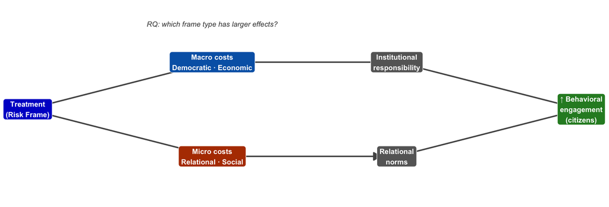

## Study Timeline

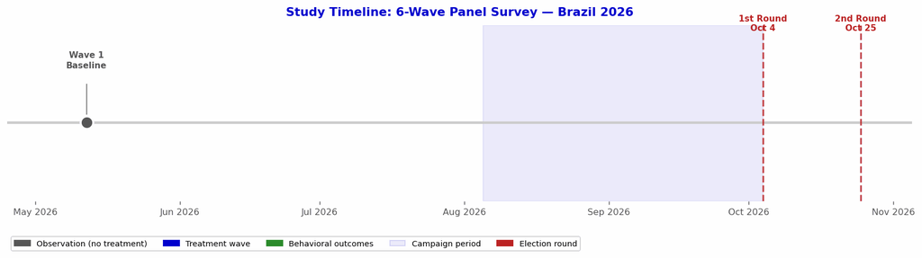

## Context: Brazil 2026

**Why Brazil?**

- 2022 election produced record-high polarization between PT and anti-PT camps
- Presidential race ongoing: Lula vs. Flávio Bolsonaro likely second round
- WhatsApp is the primary arena for political conflict among ordinary citizens
- Redes Cordiais — established NGO working on online conflict de-escalation

**Why this moment?**

# Baseline Data

## Is Brazil Heading in the Right Direction?

[figure not shown]

Same question, same country, same moment — completely different realities. Petistas: 84% right direction. Antipetistas: 83% wrong direction. Non-partisans are evenly split. This perceptual divide directly motivates the *macro* treatment frames.

## Brazil’s Biggest Problem Today

[figure not shown]

Weighted baseline survey, Wave 1, *N* ≈ 5,900. Economy includes unemployment, inflation, wages, inequality, taxes, growth. Security & Social includes violence, poverty, health, education, environment.

## Brazil’s Biggest Problem: by Partisan Group

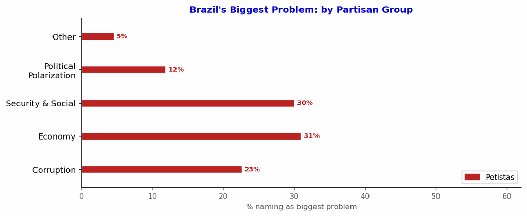

Antipetistas are over twice as likely to name **Corruption** (48% vs 23%). Petistas are four times more likely to name **Political Polarization** (12% vs 3%).

## How Brazilians Get Political News

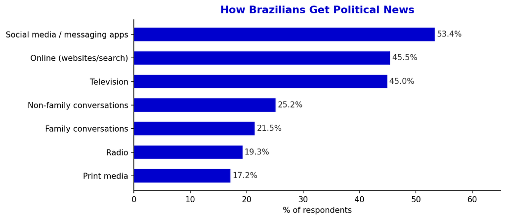

**Key finding**

**Social media and messaging apps** are the dominant source of political news (53%), surpassing television and online search.

**Implication**

WhatsApp groups are the primary arena for political conflict — making them the right target for citizen-level interventions.

## Platforms for Political Content

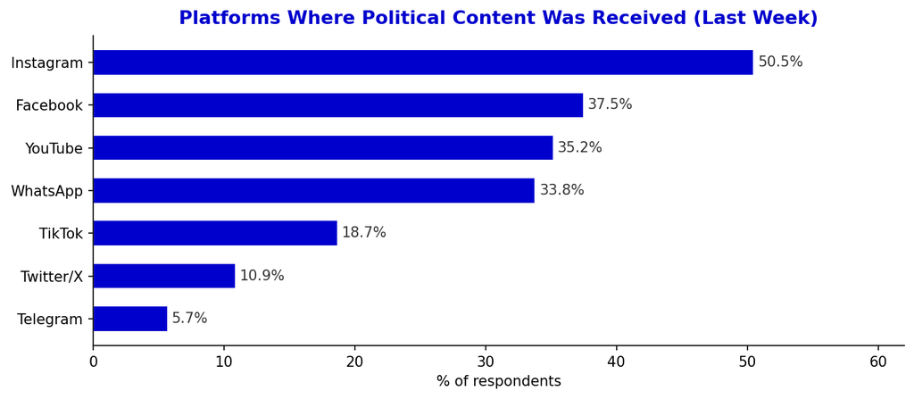

**Key finding**

**Design relevance**

Instagram + Facebook coverage justifies Meta ad targeting for the **elite experiment**.

## Sources of Political News, by Partisan Group

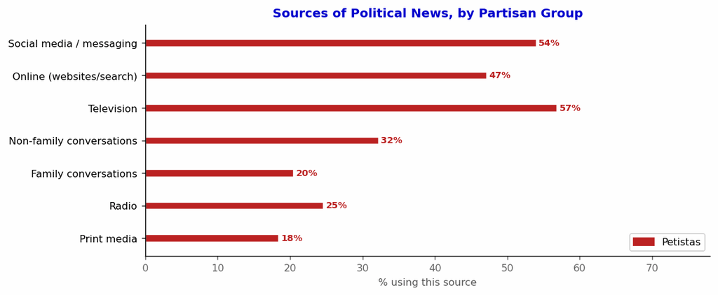

Petistas rely more heavily on **television** (57% vs 38%). Antipetistas are the heaviest users of **social media** (64%) and **online** sources. Non-partisans show lower engagement across all channels.

## Frequency of Active Political Content Seeking

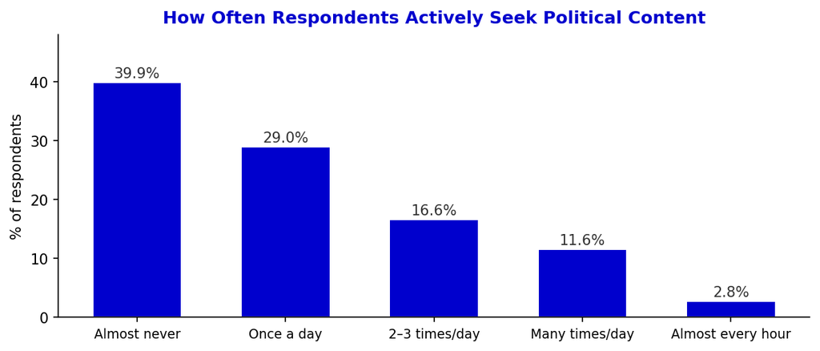

## Exposure to Online Political Conflict

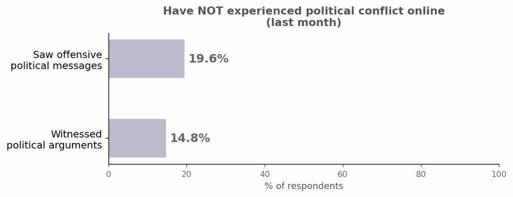

Weighted baseline survey, Wave 1, *N* ≈ 5,900.

## Exposure to Online Political Conflict, by Partisan Group

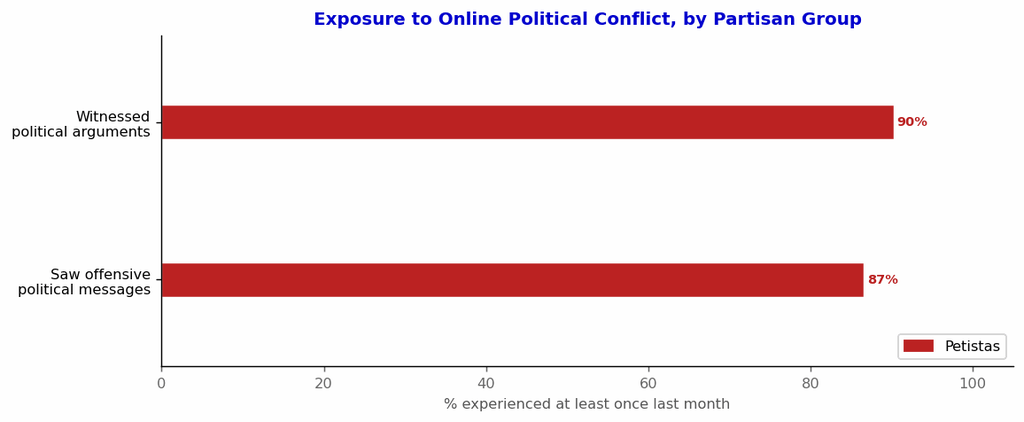

Petistas are most exposed: 87–90% experienced conflict online in the last month. Non-partisans are least exposed (72–78%), yet still a large majority — conflict reaches across the political spectrum.

## More Exposure → More Avoidance

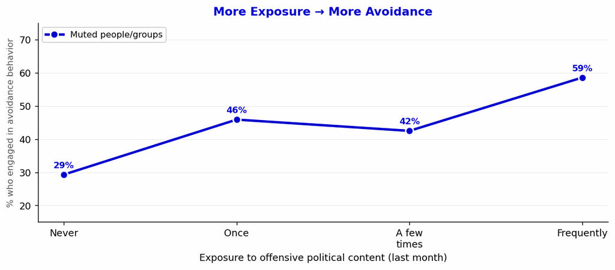

Among those frequently exposed to offensive political content, **muting** rises by +29 pp and **leaving groups** by +28 pp compared to those with no exposure. The most exposed respondents are also the most likely to disengage — the opposite of what an engaged citizenry requires.

## Avoidance Behaviors Due to Political Conflict

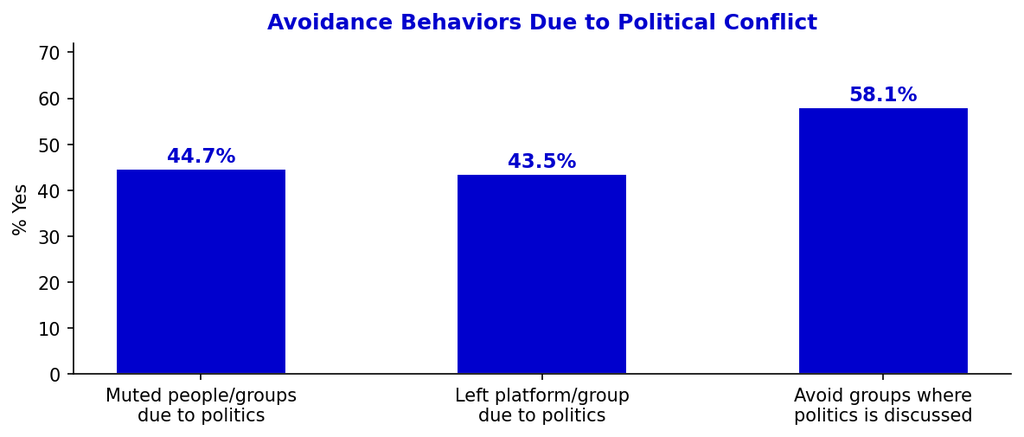

## Avoidance Behaviors by Partisan Group

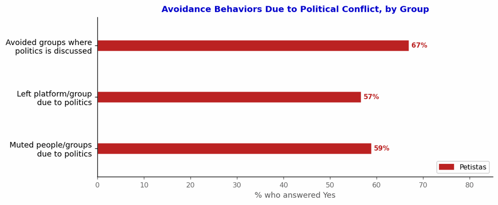

Petistas = PT as favourite party · Antipetistas = PT as least favourite · Non-partisans = all others. Petistas show the highest avoidance rates across all three behaviors.

## Feeling Thermometers: Full Matrix by Partisan Group

[figure not shown]

## Affective Polarization: In-group vs. Out-group Thermometers

[figure not shown]

# Survey Experiment Design

## Five-Wave Panel

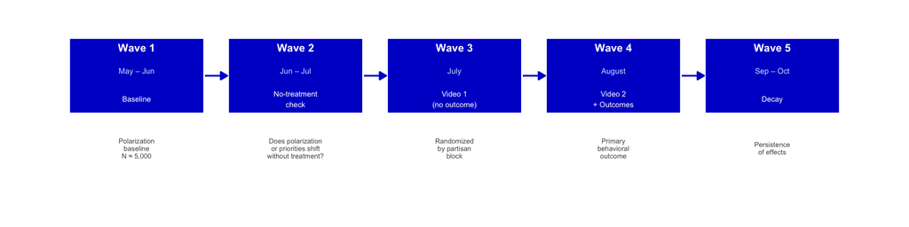

**Randomization:** block-randomized by partisan group (PT supporters / Anti-PT / Neutral) · **Retention incentive:** lottery of 3 prizes for panelists completing all waves

## Treatment Arms: Four Informational Frames

**🏛️ Macro Frames**

**Democratic Deterioration** Polarization undermines electoral trust, weakens institutions, reduces acceptance of outcomes.

**Economic Deterioration** Polarization increases uncertainty, discourages investment, generates gridlock, slows growth.

**👨‍👩‍👧 Micro Frames**

**Social Conflict** Polarization increases everyday hostility, normalizes aggression, reduces social trust.

**Family Conflict** Polarization damages family relationships, causes estrangement and lasting relational harm.

| **Control** | No informational frame; outcome measurement only |
| --- | --- |

Identical content across survey and field experiments.

## Treatment Video — Democratic Deterioration

▶

Democratic Deterioration — Treatment Video

## Treatment Video — Economic Deterioration

▶

Economic Deterioration — Treatment Video

## Treatment Video — Social Conflict

[video not shown]

## Treatment Video — Family Conflict

[video not shown]

## Primary Behavioral Outcomes

**Primary: Seminar Enrollment**

After treatment, respondents are offered free enrollment in a **1-hour online seminar** organized by *Redes Cordiais*:

- Practical strategies for polarizing content
- Responding to misinformation

**Enrollment click = primary outcome**

**Secondary: Manual Download**

Respondents are offered a downloadable **practical manual** with tips for managing political conflict in WhatsApp groups.

Download click = secondary behavioral outcome.

**Why behavioral?**

Both outcomes require active choice, not just stated willingness. Low cost & low social desirability bias.

## Secondary Outcomes and Mechanisms

**Secondary outcomes (voters)**

- Stated willingness to intervene in WhatsApp conflicts
- Self-reported corrective behavior (subsequent waves)
- Support for democratic norms / election acceptance

**Mechanisms**

- Perceived costs of polarization (macro / micro index)
- Perceived efficacy of intervention
- Perceived social cost of speaking up

**Placebo / “Should not move”**

- Partisan compromise attitudes
- Anti-democratic norm trade-offs (e.g., bypassing courts)
- Affective polarization thermometers

If behavioral outcomes move *without* thermometers moving, we confirm action ≠ attitude change.

## Power Analysis

[figure not shown]

Monte Carlo simulation (4,000 draws per cell) · **3-arm design**: Control, Macro, Micro — equal allocation within partisan blocks · Pooled treatment vs. control · Petistas & Non-partisans receive the full group effect; Antipetistas receive no effect · Assumed baseline rates: manual download = 15%, seminar enrollment = 8% · ★ ≥ 80% power · ★★ ≥ 90% power

## Expected Results — Concern about Polarization

[figure not shown]

Simulated data for illustration · Treatment group shows increased concern about polarization from Wave 3 onwards · Control group remains stable around baseline · Effect consolidates at Wave 4 and persists through Wave 5

# Hypotheses

## Pre-Registered Hypotheses

| **H1** | **Manipulation check:** Each treatment increases perceived costs in its corresponding domain (macro vs. micro) |
| --- | --- |
| **H2** | Any treatment **increases behavioral engagement** among voters vs. control |
| **H3** | Macro frames increase behavioral engagement vs. **control** |
| **H4** | Micro frames increase behavioral engagement vs. **control** |
| **H5** | Effects are **mediated** by increased perceived costs and perceived efficacy |
| **H6** | Behavioral effects may occur **without** changes in affective polarization |

**Research Question**

Which type of message — macro (democratic/economic) or micro (social/family) — produces larger behavioral effects among voters?

# Field Experiment

## Targeting Political Elites

**Population & Scale**

- Almost 30,000 candidates for Federal and State Deputy
- Identified via official electoral records (TSE)
- Verified public Meta accounts (Facebook & Instagram)
- **Over 25,000 candidate emails** extracted from official records

**Delivery**

1. Paid Meta advertisements in candidates’ own social media environments
2. Direct email campaign with treatment videos
3. Individual-level randomization across 5 arms

**Outcome Measurement**

**Polarizing rhetoric** in public posts during campaign period via **supervised text classification**:

- Delegitimizing opponents
- Framing rivals as threats
- Inflammatory language

**Secondary**

Depolarizing cues (civility, bridge-building) and democratic norm compliance

## Partnership with Redes Cordiais

[figure not shown]

**Who they are**

- Leading Brazilian NGO focused on online conflict de-escalation
- Experience training citizens to respond to polarizing content
- Recognized credibility across political groups

**Role in the study**

- Co-host of the 1-hour intervention seminar (primary behavioral outcome)
- Provide the practical manual for WhatsApp conflict
- Lend legitimacy to the intervention materials

## Partnership with Redes Cordiais (cont.)

[figure not shown]

**Why this partnership matters**

The behavioral outcome is not hypothetical — enrollment links to a **real, existing program**. This eliminates demand effects and ensures real-world impact beyond the experiment.

**Agreement status**

Formal agreement with Redes Cordiais in place for seminar delivery and content collaboration.

## Showing Voters Dislike Polarization

**The mechanism for elites**

- Candidates face electoral incentives
- Treatment reveals a **credible signal**: voters are concerned about polarization’s costs
- Provides reputational & governance rationale to moderate rhetoric

**Campaign channels**

1. Instagram & Facebook paid ads (Meta targeting)
2. Direct email to 25,000+ candidate emails
3. Content mirrors the four informational frames

**Key message to elites**

“Brazilian voters across the spectrum are concerned about how polarization harms [democracy / the economy / families / communities]. Your rhetoric affects these outcomes.”

**Identification advantage**

Simultaneous elite + citizen intervention allows testing whether **supply and demand changes reinforce each other**.

# Summary

## Summary

**What we are doing**

**Why it matters**

- Tests whether *framing* polarization costs is enough to trigger action — without requiring attitude change
- First study to intervene simultaneously on both elites and citizens using identical frames
- Real-world partnership with Redes Cordiais ensures external validity
- Results speak to the possibility of **behavioral depolarization** even in highly divided polities

**Core contribution**

Concern about polarization is widespread. AWARE tests whether it can be converted into action.